# Replication material for: What makes ethnic majorities support the radical right? A combination of relative deprivation and social dominance approaches

Domantas Undzėnas[^1]

# Setup

```r
# this will check whether you have installed the packages needed and install/load them

knitr::opts_chunk$set(echo = TRUE)

p_needed <-
  c("viridis", "knitr", "MASS", "fastDummies", "mlogit", "sensemakr", "psych", "stargazer", "dagitty", "gtrendsR", "tidyverse", "car", "piecewiseSEM", "kableExtra", "jmv", "broom")

packages <- rownames(installed.packages())

p_to_install <- p_needed[!(p_needed %in% packages)]

if (length(p_to_install) > 0) {
  install.packages(p_to_install)
}

sapply(p_needed, require, character.only = TRUE)
```

```
## See details in:
```

```
## Carlos Cinelli and Chad Hazlett (2020). Making Sense of Sensitivity: Extending Omitted Variable Bias. Journal of the Royal Statistical Society, Series B (Statistical Methodology).
```

```
##  Hlavac, Marek (2022). stargazer: Well-Formatted Regression and Summary Statistics Tables.
```

```
##  R package version 5.2.3. https://CRAN.R-project.org/package=stargazer
```

```
## ✖ ggplot2::%+%()   masks psych::%+%()
```

[output not shown]

```
##      viridis        knitr         MASS  fastDummies       mlogit    sensemakr
##         TRUE         TRUE         TRUE         TRUE         TRUE         TRUE
##        psych    stargazer      dagitty     gtrendsR    tidyverse          car
##         TRUE         TRUE         TRUE         TRUE         TRUE         TRUE
## piecewiseSEM   kableExtra          jmv        broom
##         TRUE         TRUE         TRUE         TRUE
```

```r
#loads the data

# main BES data

bes <- readRDS("data/besW15.rds")

# with atuthoritarianism

bes_auth <- readRDS("data/besW15_auth.rds")

# wave 21 with authoritarianism

bes_auth_21 <- readRDS("data/besW21_auth.rds")

# wave 15 with left-right scale

bes_lr <- readRDS("data/besW15_lr.rds")

bes <- haven::zap_labels(bes)

bes_full <- bes

# only White Britons

bes <- bes[bes$p_ethnicity == 1,]
```

# Reliability measures for SDO

```r
# calculating the reliability parameters

reliability_params <- reliability(
    data = bes,
    vars = c(
        "sdoantiegal1",
        "sdoantiegal2",
        "sdoantiegal3",
        "sdoantiegal4",
        "sdodominance1",
        "sdodominance2",
        "sdodominance3",
        "sdodominance4"),
    omegaScale = T,
    meanScale = T,
    sdScale = T,
    corPlot = T,
    alphaItems = T,
    omegaItems = T,
    meanItems = T,
    sdItems = T,
    itemRestCor = T)

omega_alpha <- reliability_params$scale$asDF
```

# Descriptive plots

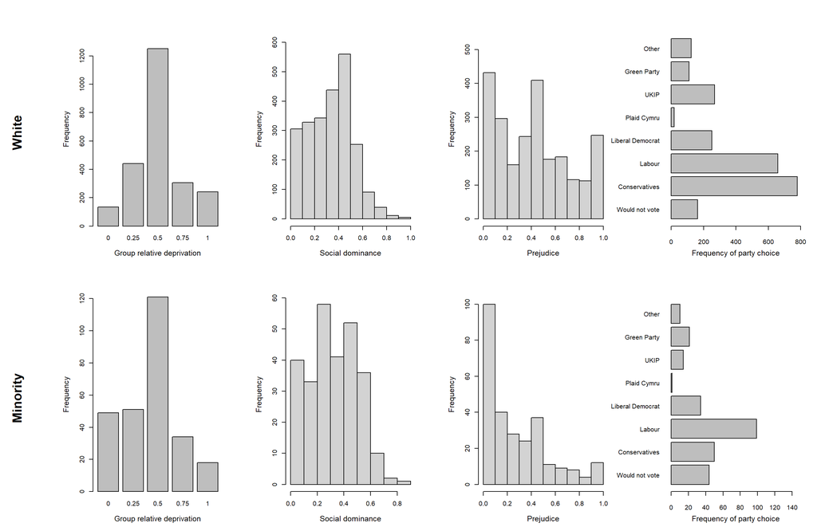

Distributions of the variables of interest for White and ethnic minority Britons

```r
# Global layout
par(mfrow = c(2, 4), mar = c(5, 6, 4, 2) + 0.1, oma = c(0, 6, 0, 0),
    cex.lab = 1.2, cex.axis = 1, cex.main = 1.2)


# White Britons

barplot(
  table(bes_full$grd[bes_full$p_ethnicity == 1]),
  xlab = "Group relative deprivation",
  ylab = "Frequency",
  ylim = c(0, max(table(bes_full$grd)))
)

hist(
  bes_full$sdo[bes_full$p_ethnicity == 1],
  main = "",
  xlab = "Social dominance",
  ylim = c(0, max(hist(bes_full$sdo, plot = F)$counts))
)

hist(
  bes_full$immig_att[bes_full$p_ethnicity == 1],
  main = "",
  xlab = "Prejudice",
  ylim = c(0, max(hist(bes_full$immig_att, plot = F)$counts))
)


par(mgp = c(3, 1.5, 0))

vote_white <- table(bes_full$generalElectionVote[bes_full$p_ethnicity == 1])
vote_min   <- table(bes_full$generalElectionVote[bes_full$p_ethnicity == 0])


barplot(
  vote_white,
  horiz = T,
  las = 1,
  cex.names = 1,
  xlab = "Frequency of party choice",
  names.arg = c(
    "Would not vote",
    "Conservatives",
    "Labour",
    "Liberal Democrat",
    "Plaid Cymru",
    "UKIP",
    "Green Party",
    "Other"
  ),
  xlim = c(0,800)
)

# Ethnic minorities

par(mgp = c(3, 1, 0))

barplot(
  table(bes_full$grd[bes_full$p_ethnicity == 0]),
  xlab = "Group relative deprivation",
  ylab = "Frequency",
  ylim = c(0, max(table(bes_full$grd[bes_full$p_ethnicity == 0])))
)

hist(
  bes_full$sdo[bes_full$p_ethnicity == 0],
  main = "",
  xlab = "Social dominance",
  ylim = c(0, max(hist(bes_full$sdo[bes_full$p_ethnicity == 0], plot = F)$counts))
)

hist(
  bes_full$immig_att[bes_full$p_ethnicity == 0],
  main = "",
  xlab = "Prejudice",
  ylim = c(0, max(hist(bes_full$immig_att[bes_full$p_ethnicity == 0], plot = F)$counts))
)

# Vote choice (minority) with adjusted label spacing
par(mgp = c(3, 1.5, 0))
barplot(
  vote_min,
  horiz = T,
  las = 1,
  cex.names = 1,
  xlab = "Frequency of party choice",
  names.arg = c(
    "Would not vote",
    "Conservatives",
    "Labour",
    "Liberal Democrat",
    "Plaid Cymru",
    "UKIP",
    "Green Party",
    "Other"
  ),
  xlim = c(0,150)
)

# Labels

mtext("White", side = 2, outer = T, line = 3, at = 0.75, cex = 1.3, font = 2)
mtext("Minority", side = 2, outer = T, line = 3, at = 0.25, cex = 1.3, font = 2)
```

# Main analyses

```r
# setting the number of simulations I use

nsim <- 1000

# random seed for reproducibility

set.seed(28042023)

# number 1, GRD -> SDO

mod1 <- lm(sdo ~ grd + ird + gender + age + factor(p_education) + p_gross_household + factor(urban), data = bes)

# summary for checking results. note that the labels here are not informative

summary(mod1)
```

```
##
## Call:
## lm(formula = sdo ~ grd + ird + gender + age + factor(p_education) +
##     p_gross_household + factor(urban), data = bes)
##
## Residuals:
##      Min       1Q   Median       3Q      Max
## -0.47077 -0.13662  0.01112  0.12927  0.64618
##
## Coefficients:
##                        Estimate Std. Error t value Pr(>|t|)
## (Intercept)           0.2344223  0.0289179   8.106 8.27e-16 ***
## grd                   0.1835668  0.0171421  10.709  < 2e-16 ***
## ird                  -0.0268544  0.0207832  -1.292  0.19644
## gender               -0.0228905  0.0075059  -3.050  0.00232 **
## age                   0.0011672  0.0002532   4.610 4.23e-06 ***
## factor(p_education)2 -0.0352736  0.0158355  -2.228  0.02601 *
## factor(p_education)3 -0.0876988  0.0167391  -5.239 1.76e-07 ***
## factor(p_education)4 -0.0354940  0.0184611  -1.923  0.05465 .
## p_gross_household     0.0065820  0.0011352   5.798 7.60e-09 ***
## factor(urban)1       -0.0038621  0.0084361  -0.458  0.64713
## ---
## Signif. codes:  0 '***' 0.001 '**' 0.01 '*' 0.05 '.' 0.1 ' ' 1
##
## Residual standard error: 0.1801 on 2364 degrees of freedom
## Multiple R-squared:  0.1064, Adjusted R-squared:  0.103
## F-statistic: 31.28 on 9 and 2364 DF,  p-value: < 2.2e-16
```

```r
# doing the same but adding wave 14 authoritarianism

mod1_a <- lm(sdo ~ grd + auth + ird + gender + age + factor(p_education) + p_gross_household + factor(urban), data = bes_auth[bes_auth$p_ethnicity == 1,])

# summary for checking results. note that the labels here are not informative


mod2_a <- lm(auth ~ grd + ird + gender + age + factor(p_education) + p_gross_household + factor(urban), data = bes_auth_21[bes_auth_21$p_ethnicity == 1,])


# simulating

sim_func <- function(nsim, beta, varcov){

  S <- mvrnorm(nsim, beta, varcov)

  return(S)
}

# simulates alternative worlds

S <- sim_func(nsim, beta = mod1$coefficients, varcov = vcov(mod1))

# gets the data matrix for observed value approach

ova_X <- as.matrix(cbind(1, bes$grd, bes$ird, bes$gender, bes$age, dummy_cols(bes$p_education)[,-c(1,2)], bes$p_gross_household, bes$urban))

# preparing to set up scenarios

cases <- array(NA, c(dim(ova_X), 2))

cases[, ,] <- ova_X

# setting the scenario where everyone either has no relative deprivation vs large relative deprivation

sel <- which(colnames(ova_X) == "bes$grd")

cases[, sel, 1] <-  0

cases[, sel, 2] <-  1

# putting in the simulated SDO scores here

val <- matrix(NA, nrow = nsim, ncol = 2)

for (i in 1:2) {

  val[,i] <- apply(S%*%t(cases[,,i]),1, mean)

}

# first differences in SDO scores between no relative deprivation vs high relative deprivation

fd <- val[,2] - val[,1]
```

```r
# another random seed

set.seed(02052023)

# analysis number 2 SDO -> Prejudice aganst immigrants

mod2 <- lm(immig_att ~ sdo  + gender + age + factor(p_education) + p_gross_household + factor(urban), data = bes)

summary(mod2)
```

```
##
## Call:
## lm(formula = immig_att ~ sdo + gender + age + factor(p_education) +
##     p_gross_household + factor(urban), data = bes)
##
## Residuals:
##      Min       1Q   Median       3Q      Max
## -0.79197 -0.19353 -0.02805  0.17391  0.83414
##
## Coefficients:
##                        Estimate Std. Error t value Pr(>|t|)
## (Intercept)           0.2565595  0.0409880   6.259 4.57e-10 ***
## sdo                   0.6639528  0.0295017  22.506  < 2e-16 ***
## gender               -0.0005704  0.0110725  -0.052 0.958918
## age                   0.0012448  0.0003738   3.330 0.000882 ***
## factor(p_education)2 -0.0365640  0.0233455  -1.566 0.117433
## factor(p_education)3 -0.1317870  0.0247706  -5.320 1.13e-07 ***
## factor(p_education)4 -0.0949549  0.0272089  -3.490 0.000492 ***
## p_gross_household    -0.0083659  0.0016606  -5.038 5.07e-07 ***
## factor(urban)1        0.0229862  0.0124222   1.850 0.064378 .
## ---
## Signif. codes:  0 '***' 0.001 '**' 0.01 '*' 0.05 '.' 0.1 ' ' 1
##
## Residual standard error: 0.2653 on 2365 degrees of freedom
## Multiple R-squared:  0.2491, Adjusted R-squared:  0.2465
## F-statistic: 98.05 on 8 and 2365 DF,  p-value: < 2.2e-16
```

```r
# simulates alternative worlds

S <- sim_func(nsim, beta = mod2$coefficients, varcov = vcov(mod2))

# gets the data matrix for observed value approach

ova_X <- as.matrix(cbind(1, bes$sdo, bes$gender, bes$age, dummy_cols(bes$p_education)[,-c(1,2)], bes$p_gross_household, bes$urban))

# preparing to set up scenarios

cases <- array(NA, c(dim(ova_X), 2))

cases[, ,] <- ova_X

# setting the scenario where the first value is the mean of the estimated SDO scores of no GRD people with the second value is being estimated with the estimated SDO scores of people with high GRD

sel <- which(colnames(ova_X) == "bes$sdo")

cases[, sel, 1] <- rnorm(n = nrow(bes), mean = mean(val[,1]), sd = sd(val[,1]))

cases[, sel, 2] <- rnorm(n = nrow(bes), mean = mean(val[,2]), sd = sd(val[,2]))


# putting in the simulated SDO scores here

val2 <- matrix(NA, nrow = nsim, ncol = 2)

for (i in 1:2) {

  val2[,i] <- apply(S%*%t(cases[,,i]),1, mean)

}

# differences in prejudice scores between no relative deprivation vs high relative deprivation

fd2 <- val2[,2] - val2[,1]
```

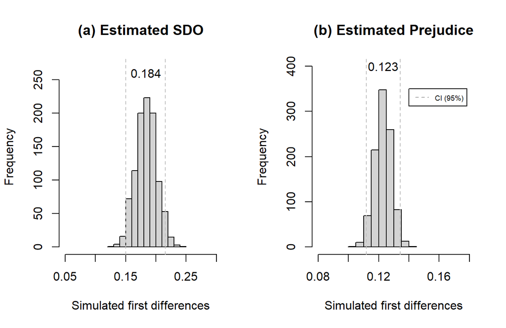

Empirical distributions of the estimated effects of GRD on SDO and SDO on prejudice

```r
par(mfrow = c(1, 2))

# histogram of first differences 1

hist(fd, xlim = c(0.05, 0.3), ylim = c(0, 270), main = "(a) Estimated SDO", xlab = "Simulated first differences")
abline(
  v = quantile(fd, c(0.025, 0.975)),
  col = "grey",
  lty = "dashed"
)
text(mean(fd), 260, round(mean(fd), 3))

# histogram 2

hist(fd2, xlim = c(0.08, 0.18), ylim = c(0, 400), main = "(b) Estimated Prejudice", xlab = "Simulated first differences")
abline(
  v = quantile(fd2, c(0.025, 0.975)),
  col = "grey",
  lty = "dashed"
)
text(mean(fd2), 400, round(mean(fd2), 3))
legend(0.14, 350, legend=c("CI (95%)"),
       col=c("darkgrey"), lty=2, cex=0.6)
```

```r
# analysis part 3 Immigration attitudes -> Radical right voting

# this prepares the data for a multinomial logit

bes$generalElectionVote <- factor(bes$generalElectionVote)
bes$generalElectionVote <- relevel(bes$generalElectionVote, ref = "0")

# turns data into the "wide" format

bes2 <- mlogit.data(data = bes, choice = "generalElectionVote", shape = "wide")

# and runs the multinomial logit regression
# here, it only has chooser(individual)-specific covariates

mod3 <- mlogit(generalElectionVote ~ 0 | immig_att + gender + age + factor(p_education) + p_gross_household + factor(urban), data = bes2,  reflevel = "0")

summary(mod3)
```

```
##
## Call:
## mlogit(formula = generalElectionVote ~ 0 | immig_att + gender +
##     age + factor(p_education) + p_gross_household + factor(urban),
##     data = bes2, reflevel = "0", method = "nr")
##
## Frequencies of alternatives:choice
##         0         1         2         3         5         6         7         9
## 0.0686605 0.3281382 0.2771693 0.1057287 0.0080034 0.1133109 0.0467565 0.0522325
##
## nr method
## 7 iterations, 0h:0m:2s
## g'(-H)^-1g = 8.77E-05
## successive function values within tolerance limits
##
## Coefficients :
##                          Estimate Std. Error  z-value  Pr(>|z|)
## (Intercept):1          -1.2239655  0.6611435  -1.8513 0.0641285 .
## (Intercept):2           3.3911269  0.6845504   4.9538 7.278e-07 ***
## (Intercept):3           0.3862110  0.8411516   0.4591 0.6461296
## (Intercept):5          -2.9882995  1.9865234  -1.5043 0.1325077
## (Intercept):6          -1.8493809  0.7714270  -2.3974 0.0165141 *
## (Intercept):7           1.1840131  0.9863516   1.2004 0.2299853
## (Intercept):9          -1.3474281  0.9472157  -1.4225 0.1548769
## immig_att:1            -0.7944346  0.3231364  -2.4585 0.0139514 *
## immig_att:2            -4.3150862  0.3568707 -12.0915 < 2.2e-16 ***
## immig_att:3            -4.9692901  0.4364419 -11.3859 < 2.2e-16 ***
## immig_att:5            -5.7681710  1.2135158  -4.7533 2.002e-06 ***
## immig_att:6             1.6720760  0.3869192   4.3215 1.550e-05 ***
## immig_att:7            -4.7465708  0.5409988  -8.7737 < 2.2e-16 ***
## immig_att:9            -1.7842469  0.4495461  -3.9690 7.218e-05 ***
## gender:1                0.2860896  0.1774491   1.6122 0.1069109
## gender:2                0.1799628  0.1882066   0.9562 0.3389721
## gender:3               -0.2558418  0.2177069  -1.1752 0.2399282
## gender:5                0.2465904  0.5028443   0.4904 0.6238571
## gender:6               -0.2450874  0.2055027  -1.1926 0.2330167
## gender:7                0.2335492  0.2601448   0.8978 0.3693102
## gender:9               -0.4380115  0.2541353  -1.7235 0.0847914 .
## age:1                   0.0272968  0.0064143   4.2556 2.085e-05 ***
## age:2                  -0.0139562  0.0065329  -2.1363 0.0326561 *
```

[output cut: 31 more lines]

```
## p_gross_household:7     0.0257079  0.0398971   0.6444 0.5193447
## p_gross_household:9     0.1532696  0.0387488   3.9555 7.638e-05 ***
## factor(urban)1:1        0.0910598  0.1986989   0.4583 0.6467510
## factor(urban)1:2        0.2522925  0.2123646   1.1880 0.2348272
## factor(urban)1:3       -0.0212738  0.2397516  -0.0887 0.9292943
## factor(urban)1:5       -0.6788679  0.5077014  -1.3371 0.1811770
## factor(urban)1:6       -0.2520036  0.2246192  -1.1219 0.2618987
## factor(urban)1:7        0.4061562  0.3094710   1.3124 0.1893782
## factor(urban)1:9       -0.1310752  0.2701390  -0.4852 0.6275248
## ---
## Signif. codes:  0 '***' 0.001 '**' 0.01 '*' 0.05 '.' 0.1 ' ' 1
##
## Log-Likelihood: -3525.6
## McFadden R^2:  0.13935
## Likelihood ratio test : chisq = 1141.6 (p.value = < 2.22e-16)
```

```r
# simulating again...

S <- sim_func(nsim, coef(mod3), varcov = vcov(mod3))

J <- length(unique(bes$generalElectionVote))  # Number of categories
k <- 9 # number of independent variables + intercept


# store in an array
beta_S <- array(0, dim = c(J, k, nsim))


# check dimensions
dim(beta_S)
```

```
## [1]    8    9 1000
```

```r
# fill the array with the sampling distribution of betas
for(sim in 1:nsim) {
  beta_S[-1, ,sim] <- matrix(S[sim,],
                             ncol = k,
                             byrow = F)
}

# OVA again

X <- as.matrix(cbind(1, bes$immig_att, bes$gender, bes$age, dummy_cols(bes$p_education)[,-c(1,2)],bes$p_gross_household, bes$urban))

# Set up your scenarios
n_scenarios <- 2 # Number of scenarios
cases <- array(NA, c(dim(X),
                     n_scenarios))

# put in te OVA dataset as all of the scenarios

cases[, , ] <- X

# selecting which column has the immigration attitudes

sel <- 2

cases[, sel, 1] <- rnorm(n = nrow(bes), mean = mean(val2[,1]), sd = sd(val2[,1]))
cases[, sel, 2] <- rnorm(n = nrow(bes), mean = mean(val2[,2]), sd = sd(val2[,2]))

V  <-
  array(NA,
        dim = c(nrow(X),       # number of observations
                J,             # number of categories
                nsim,          # number of simulations
                n_scenarios))  # number of scenarios

# loop over the scenarios
for(i in 1:n_scenarios){
  V[,,,i] <- apply(beta_S[,,], c(1,3),
                   function(bs) cases[,,i] %*% bs)
}

# dimensions again
dim(V)
```

```
## [1] 2374    8 1000    2
```

```r
# sum of all of the expected utilities to vote for parties
Sexp <- apply(V, c(1,3,4), function(v) sum(exp(v)))

#dimensions look fine
dim(Sexp)
```

```
## [1] 2374 1000    2
```

```r
# predicted probabilities of voting for each party
P <- array(NA, c(nsim, J, 2))
for (scen in 1:n_scenarios) {
  for (category in 1:J) {
    P[, category, scen] <-
      apply(exp(V[, category, , scen]) / Sexp[, , scen], 2, mean)
  }
}
# quantities of interest
# low prejudice voters
QoI0Mean <- apply(P[, , 1], 2, mean)
QoI0CI <-
  apply(P[, , 1], 2, function(x)
    quantile(x, probs = c(0.025, 0.975)))
# high prejudice voters
QoI1Mean <- apply(P[, , 2], 2, mean)
QoI1CI <-
  apply(P[, , 2], 2, function(x)
    quantile(x, probs = c(0.025, 0.975)))
```

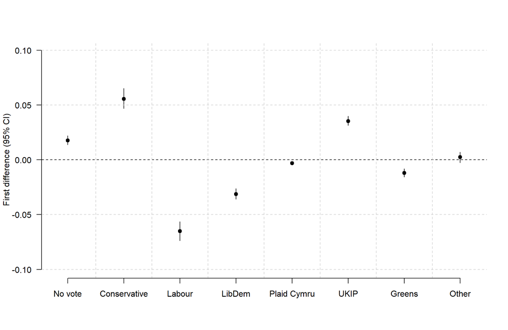

First differences in predicted probabilities of vote intention based on prejudice scenarios

```r
# first differences again, yayyy
QoIFD <- P[, , 2] - P[, , 1]

QoIFDMean <- apply(QoIFD, 2, mean)

QoIFDCI <-
  apply(QoIFD, 2, function(x)
    quantile(x, probs = c(0.025, 0.975)))

fd_seq <- seq(0,1, length.out = length(QoIFDMean))

plot(
  x = fd_seq,
  y = QoIFDMean,
  xlim = c(-0.025, 1.025),
  ylim = c(-0.1, 0.1),
  xaxt = "n",
  bty = "n",
  las = 1,
  xlab = "",
  ylab = "First difference (95% CI)",
  main = "",
  font.main = 1
)

abline(h = 0, lwd = 1, lty = "dashed", col = "black")
points(
  x = fd_seq,
  y = QoIFDMean,
  pch = 19,
  cex = 1
)

segments(
  x0 = fd_seq,
  y0 = QoIFDCI[1,],
  y1 = QoIFDCI[2,],
  lwd = 1,
  lend = 1
)
abline(v = fd_seq + (fd_seq[1]-fd_seq[2])/2,
       lty = "dashed",
       col = "lightgrey")
abline(h = seq(0.05,1, by = 0.05), lty = "dashed",
       col = "lightgrey")
abline(h = seq(-1,-0.05, by = 0.05), lty = "dashed",
       col = "lightgrey")

axis(1, fd_seq, labels = c("No vote", "Conservative", "Labour", "LibDem", "Plaid Cymru", "UKIP", "Greens", "Other"))
```

```r
# Making radical right vote choice binary

bes$rr_vote <- ifelse(bes$generalElectionVote == 6, 1, 0)

# Dummies for education

bes <- dummy_cols(bes,
                   select_columns = "p_education")



# Running the SEM

main_psem <- psem(
  lm(sdo ~ grd + ird + gender + age + p_education_2 +  p_education_3 +  p_education_4 + p_gross_household + urban , data = bes),

  lm(immig_att ~  sdo + grd  + ird + gender + age + p_education_2 +  p_education_3 +  p_education_4 + p_gross_household + urban , data = bes),

  glm(rr_vote ~ grd + sdo + immig_att + ird + gender + age + p_education_2 +  p_education_3 +  p_education_4 + p_gross_household + urban, family = binomial(link = "logit"), data = bes),

  data = bes

)


# Table for the results

coefs_psem <- summary(main_psem)$coefficients

coefs_psem <- coefs_psem[,-c(5, 8)]

coefs_psem <- modify_if(coefs_psem, ~is.numeric(.), ~round(., 2))

coefs_psem[,1] <- c("SDO", "SDO","SDO","SDO","SDO","SDO","SDO","SDO", "SDO", "Prejudice", "Prejudice","Prejudice","Prejudice","Prejudice","Prejudice","Prejudice","Prejudice", "Prejudice", "Prejudice", "RRV", "RRV","RRV","RRV","RRV","RRV","RRV","RRV","RRV","RRV", "RRV")

coefs_psem[,2] <- c("GRD", "IRD", "Female", "Age", "Below university education", "University education", "Unspecified education", "Household income", "Urban", "SDO", "GRD", "IRD", "Female", "Age", "Below university education", "University education", "Unspecified education", "Household income", "Urban", "GRD", "SDO", "Prejudice", "IRD", "Female", "Age", "Below university education", "University education", "Unspecified education", "Household income", "Urban")

kbl(coefs_psem) %>%
  kable_classic(full_width = F, html_font = "Cambria") %>%
  add_footnote("Models fit using piecewiseSEM. RRV = Radical right vote. *p < .05, **p < 0.01 , ***p < 0.001", notation="none") %>%
  cat(., file = "figures/sem_res.html")

r2_psem <- summary(main_psem)$R2
```

# Mechanism section

```r
library(DiagrammeR)
library(DiagrammeRsvg)
library(rsvg)
library(magrittr)
```

```r
SEM_plot <- grViz("
digraph CFA{

# main
node [shape=rectangle]
GRD;
SDO;
Prejudice;
RRV;

#regressions
GRD -> SDO [label='0.18***'];
GRD -> Prejudice [label='0.39***'];
GRD -> RRV [label='1.35***'];

SDO -> Prejudice [label='0.55***'];

Prejudice -> RRV [label='3.01***']

}
")

SEM_plot %>%
export_svg() %>%
charToRaw %>%
rsvg_pdf("figures/fig7.pdf")
```

# Sensitivity analysis

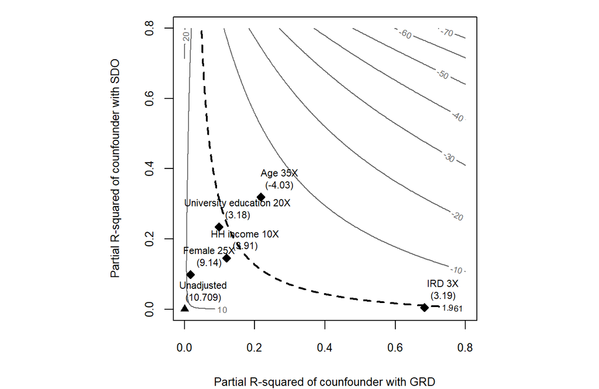

Hypothetical confounders on the GRD to SDO path and their effects on the t-values of the GRD estimate

```r
# playing around with omitted variable bias

# setting up the plot
ovb_contour_plot(mod1,
                 treatment = "grd",
                 lim = 0.8, col.thr.line = "black", sensitivity.of = "t-value", xlab = "Partial R-squared of counfounder with GRD",  ylab = "Partial R-squared of counfounder with SDO")

# adding a hypothetical confounder 5 times stronger than HH income

hh_income_x10 <- ovb_bounds(model = mod1,
                           treatment = "grd",
                           benchmark_covariates = "p_gross_household",
                           kd = 10, ky = 10)


add_bound_to_contour(bounds = hh_income_x10,
                     bound_label = "HH income 10X", point.bg = "black")


# adding a hypothetical confounder that is 20 times as strong as getting a university education compared to having no qualifications

uni_ed_x20 <- ovb_bounds(model = mod1,
                           treatment = "grd",
                           benchmark_covariates = "factor(p_education)3",
                           kd = 20, ky = 20)


add_bound_to_contour(bounds = uni_ed_x20,
                     bound_label = "University education 20X", point.bg = "black")

# adding a hypothetical confounder that is 3 times as strong as GRD

ird_x3 <- ovb_bounds(model = mod1,
                           treatment = "grd",
                           benchmark_covariates = "ird",
                           kd = 3, ky = 3)


add_bound_to_contour(bounds = ird_x3,
                     bound_label = "IRD 3X", point.bg = "black")

# adding a hypothetical confounder that is 25 times as strong as being a female

female_x25 <- ovb_bounds(model = mod1,
                           treatment = "grd",
                           benchmark_covariates = "gender",
                           kd = 25, ky = 25)


add_bound_to_contour(bounds = female_x25,
                     bound_label = "Female 25X", point.bg = "black")


# adding a confounder that is 35 times as strong as age

age_x35 <- ovb_bounds(model = mod1,
                           treatment = "grd",
                           benchmark_covariates = "age",
                           kd = 35, ky = 35)


add_bound_to_contour(bounds = age_x35,
                     bound_label = "Age 35X", point.bg = "black")
```

# Urbanska Guimond replication

```r
# loading the data

urbanska_guimond <- read.csv("data/urbanska_guimond.csv") # please download this dataset from the respective replication archive of the authors if you want to replicate it

# some data wrangling

urbanska_guimond$sdo <- scales::rescale(urbanska_guimond$sdo, to = c(0, 1))

urbanska_guimond$grd <- scales::rescale(urbanska_guimond$GRD, to = c(0, 1))

urbanska_guimond$ird <- scales::rescale(urbanska_guimond$IRD, to = c(0, 1))

urbanska_guimond$prej <- scales::rescale(urbanska_guimond$prej, to = c(0, 1))

urbanska_guimond$voteER <- scales::rescale(urbanska_guimond$voteER, to = c(0, 1))

urbanska_guimond <- urbanska_guimond[,c("sdo", "grd", "ird","prej", "voteER" )]

urbanska_guimond <- na.omit(urbanska_guimond)

mod1_u <- lm(sdo ~ grd + ird, data = urbanska_guimond)

summary(mod1_u)
```

```
##
## Call:
## lm(formula = sdo ~ grd + ird, data = urbanska_guimond)
##
## Residuals:
##      Min       1Q   Median       3Q      Max
## -0.32836 -0.14173 -0.02408  0.11991  0.76697
##
## Coefficients:
##             Estimate Std. Error t value Pr(>|t|)
## (Intercept)  0.10731    0.01831   5.861 6.72e-09 ***
## grd          0.12991    0.03147   4.128 4.04e-05 ***
## ird          0.12153    0.03672   3.310 0.000976 ***
## ---
## Signif. codes:  0 '***' 0.001 '**' 0.01 '*' 0.05 '.' 0.1 ' ' 1
##
## Residual standard error: 0.1786 on 801 degrees of freedom
## Multiple R-squared:  0.044,  Adjusted R-squared:  0.04161
## F-statistic: 18.43 on 2 and 801 DF,  p-value: 1.491e-08
```

```r
mod2_u <- lm(prej ~ sdo, data = urbanska_guimond)

summary(mod2_u)
```

```
##
## Call:
## lm(formula = prej ~ sdo, data = urbanska_guimond)
##
## Residuals:
##      Min       1Q   Median       3Q      Max
## -0.46590 -0.13898 -0.01718  0.11102  0.72640
##
## Coefficients:
##             Estimate Std. Error t value Pr(>|t|)
## (Intercept) 0.235136   0.009824   23.93   <2e-16 ***
## sdo         0.653821   0.035575   18.38   <2e-16 ***
## ---
## Signif. codes:  0 '***' 0.001 '**' 0.01 '*' 0.05 '.' 0.1 ' ' 1
##
## Residual standard error: 0.1839 on 802 degrees of freedom
## Multiple R-squared:  0.2964, Adjusted R-squared:  0.2955
## F-statistic: 337.8 on 1 and 802 DF,  p-value: < 2.2e-16
```

```r
mod3_u <- lm(voteER ~ prej, data = urbanska_guimond)

summary(mod3_u)
```

```
##
## Call:
## lm(formula = voteER ~ prej, data = urbanska_guimond)
##
## Residuals:
##     Min      1Q  Median      3Q     Max
## -0.5337 -0.3223 -0.1211  0.3047  0.7834
##
## Coefficients:
##             Estimate Std. Error t value Pr(>|t|)
## (Intercept)  0.21657    0.02667   8.122 1.73e-15 ***
## prej         0.31717    0.06193   5.121 3.80e-07 ***
## ---
## Signif. codes:  0 '***' 0.001 '**' 0.01 '*' 0.05 '.' 0.1 ' ' 1
##
## Residual standard error: 0.3845 on 802 degrees of freedom
## Multiple R-squared:  0.03167,    Adjusted R-squared:  0.03046
## F-statistic: 26.23 on 1 and 802 DF,  p-value: 3.804e-07
```

```r
urbanska_guimond_sem <- psem(
  lm(sdo ~ grd + ird, data = urbanska_guimond),
   lm(prej ~ sdo + grd  + ird , data = urbanska_guimond),
  lm(voteER ~ prej + grd + sdo + ird, data = urbanska_guimond),
  data = urbanska_guimond

)
```

# Tables for the main regressions

```r
stargazer(mod1, mod2, type = "latex", no.space = T, font.size = "tiny", omit.stat=c("ser","f"), star.char = c("*", "**", "***"), star.cutoffs = c(.05, .01, .001), notes = c("\\parbox[t]{4cm}{*p < .05, **p < .01, ***p < .001}", "Standard errors in parentheses", "Reference categories: Education - No Qualification"), notes.append = F, dep.var.labels=c("SDO","Prejudice"),covariate.labels=c("GRD", "IRD", "SDO", "Female", "Age", "Below university education", "University education", "Unspecified education", "Household income"), header = F, title = "Models 1 and 2 used for the SDO and prejudice simulations", out = "figures/tab1.html")
```

```r
stargazer(mod3, type = "latex", no.space = T, font.size = "tiny", single.row = T, star.char = c("*", "**", "***"), star.cutoffs = c(.05, .01, .001), notes = c("\\parbox[t]{4cm}{*p < .05, **p < .01, ***p < .001}", "Standard errors in parentheses", "Reference categories: Education - No Qualification", "Vote choice - Would not vote"), notes.append = F, dep.var.labels=c("General election vote"),covariate.labels=c("Intercept: Conservatives", "Intercept: Labour", "Intercept: LibDem", "Intercept: Plaid Cymru", "Intercept: UKIP", "Intercept: Greens", "Intercept: Other party", "Prejudice: Conservatives", "Prejudice: Labour", "Prejudice: LibDem", "Prejudice: Plaid Cymru", "Prejudice: UKIP", "Prejudice: Greens", "Prejudice: Other party", "Female: Conservatives", "Female: Labour", "Female: LibDem", "Female: Plaid Cymru", "Female: UKIP", "Female: Greens", "Female: Other party", "Age: Conservatives", "Age: Labour", "Age: LibDem", "Age: Plaid Cymru", "Age: UKIP", "Age: Greens", "Age: Other party", "Below university education: Conservatives", "Below university education: Labour", "Below university education: LibDem", "Below university education: Plaid Cymru", "Below university education: UKIP", "Below university education: Greens", "Below university education: Other party", "University education: Conservatives", "University education: Labour", "University education: LibDem", "University education: Plaid Cymru", "University education: UKIP", "University education: Greens", "University education: Other party", "Unspecified education: Conservatives", "Unspecified education: Labour", "Unspecified education: LibDem", "Unspecified education: Plaid Cymru", "Unspecified education: UKIP", "Unspecified education: Greens", "Unspecified education: Other party", "Household income: Conservatives", "Household income: Labour", "Household income: LibDem", "Household income: Plaid Cymru", "Household income: UKIP", "Household income: Greens", "Household income: Other party" ), header = F, title = "Model 3 used for the vote probability simulations", out = "figures/tab2.html")
```

# Are people who express GRD poorer?

```r
# the model

grd_mod <- lm(grd ~ factor(p_gross_household) + ird + age + gender + factor(p_education), data = bes)

summary(grd_mod)
```

```
##
## Call:
## lm(formula = grd ~ factor(p_gross_household) + ird + age + gender +
##     factor(p_education), data = bes)
##
## Residuals:
##      Min       1Q   Median       3Q      Max
## -0.72273 -0.13791 -0.00693  0.10541  0.66239
##
## Coefficients:
##                               Estimate Std. Error t value Pr(>|t|)
## (Intercept)                  0.3363858  0.0425082   7.913 3.82e-15 ***
## factor(p_gross_household)2  -0.0774068  0.0371633  -2.083 0.037369 *
## factor(p_gross_household)3  -0.0936506  0.0346826  -2.700 0.006979 **
## factor(p_gross_household)4  -0.0925871  0.0346706  -2.670 0.007626 **
## factor(p_gross_household)5  -0.1257917  0.0344959  -3.647 0.000272 ***
## factor(p_gross_household)6  -0.1179288  0.0344790  -3.420 0.000636 ***
## factor(p_gross_household)7  -0.1383356  0.0350567  -3.946 8.18e-05 ***
## factor(p_gross_household)8  -0.1174268  0.0358933  -3.272 0.001085 **
## factor(p_gross_household)9  -0.1639654  0.0358963  -4.568 5.18e-06 ***
## factor(p_gross_household)10 -0.1377298  0.0366038  -3.763 0.000172 ***
## factor(p_gross_household)11 -0.1501237  0.0359424  -4.177 3.06e-05 ***
## factor(p_gross_household)12 -0.1351059  0.0373717  -3.615 0.000306 ***
## factor(p_gross_household)13 -0.1501903  0.0361709  -4.152 3.41e-05 ***
## factor(p_gross_household)14 -0.1486585  0.0425935  -3.490 0.000492 ***
## factor(p_gross_household)15 -0.2282194  0.0600636  -3.800 0.000149 ***
## ird                          0.5252544  0.0225405  23.303  < 2e-16 ***
## age                          0.0012506  0.0003051   4.100 4.28e-05 ***
## gender                      -0.0110964  0.0090114  -1.231 0.218306
## factor(p_education)2        -0.0132389  0.0190441  -0.695 0.487016
## factor(p_education)3        -0.0673497  0.0200768  -3.355 0.000807 ***
## factor(p_education)4        -0.0203206  0.0221365  -0.918 0.358730
## ---
## Signif. codes:  0 '***' 0.001 '**' 0.01 '*' 0.05 '.' 0.1 ' ' 1
##
## Residual standard error: 0.2159 on 2353 degrees of freedom
## Multiple R-squared:  0.2196, Adjusted R-squared:  0.213
## F-statistic: 33.11 on 20 and 2353 DF,  p-value: < 2.2e-16
```

```r
# random seed for reproducibility

set.seed(10102023)

# simulates alternative worlds

S <- sim_func(nsim, beta = grd_mod$coefficients, varcov = vcov(grd_mod))

# gets the data matrix for observed value approach

ova_X <- as.matrix(cbind(1, dummy_cols(bes$p_gross_household)[,-c(1,2)], bes$ird,  bes$age, bes$gender, dummy_cols(bes$p_education)[,-c(1,2)]))

# preparing to set up scenarios

cases <- array(NA, c(dim(ova_X), 5))

cases[, ,] <- ova_X


# we make everyone super poor here

cases[, 2:15, 1] <- 0

# and then make everyone have median HH income

cases[, 2:15, 2] <- 0

cases[, median(bes$p_gross_household), 2] <- 1

# and now everyone is super rich!

cases[, 2:15, 3] <- 0

cases[, max(bes$p_gross_household), 3] <- 1

# 2nd lowest income category

cases[, 2:15, 4] <- 0

cases[, min(bes$p_gross_household) + 1, 4] <- 1

# 2nd highest income category

cases[, 2:15, 5] <- 0

cases[, max(bes$p_gross_household) - 1, 5] <- 1

# putting in the simulated GRD scores here

val <- matrix(NA, nrow = nsim, ncol = 5)

for (i in 1:5) {

  val[,i] <- apply(S%*%t(cases[,,i]),1, mean)

}

# first differences in GRD scores between different income brackets

# median vs poor

fd_median_poor <- val[,2] - val[,1]

# rich vs poor

fd_rich_poor <- val[,3] - val[,1]

# rich vs median

fd_rich_median <- val[,3] - val[,2]

# median vs 2nd lowest

fd_median_2low <-  val[,2] - val[,4]

#2nd highest vs 2nd lowest

fd_2high_2low <- val[,5] - val[,4]


# now some simulations for points

sim_vals <- matrix(NA, nrow = nsim, ncol = length(unique(bes$p_gross_household)))

for (i in 1:15) {

  ova_X[, 2:15] <- 0

# cool thing: the first row is just the intercept, so these
# lines still work for getting the reference category sims!

  ova_X[, i] <- 1

  sim_vals[,i] <- apply(S%*%t(ova_X),1, mean)

}
```

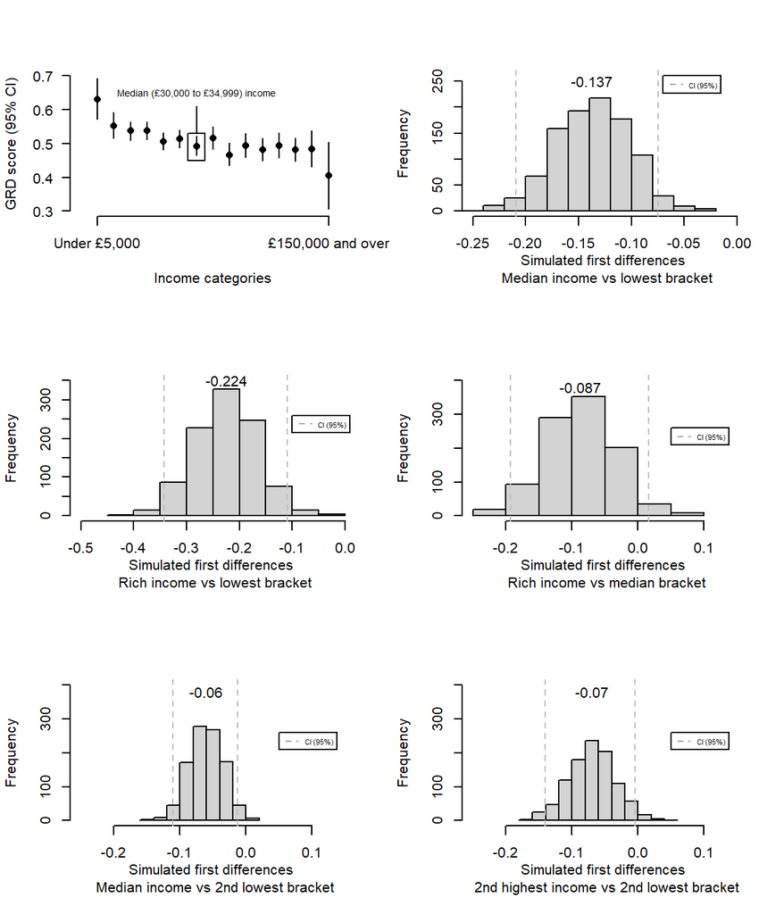

Simulated GRD scores between income conditions and first differences between scenarios

```r
par(mfrow = c(3, 2))

# expected values of GRD

plot(
  x = seq(1, 15, length.out = dim(sim_vals)[2]),
  y = colMeans(sim_vals),
  ylim = c(0.3, 0.7),
  xlim = c(0, 16),
  xaxt = "n",
  bty = "n",
  las = 1,
  xlab = "Income categories",
  ylab = "GRD score (95% CI)",
  main = "",
  pch = 16
)

segments(
  x0 = 1:15,
  y0 = apply(sim_vals, 2, quantile, probs = 0.025),
  y1 = apply(sim_vals, 2, quantile, probs = 0.975),
  lwd = 1,
  lend = 1
)

axis(1, c(1, 15), labels = c("Under £5,000", "£150,000 and over"))

rect(xleft = 6.5, xright = 7.5, ybottom = 0.45, ytop = 0.53)

segments(
  x0 = 7,
  y0 = 0.53,
  y1 = 0.61,
  lwd = 1,
  lend = 1
)

text(7, 0.65, "Median (£30,000 to £34,999) income", cex = 0.65)




# median - poor

hist(fd_median_poor, xlim = c(-0.25, 0), ylim = c(0, 260), main = "", xlab = "Simulated first differences \n Median income vs lowest bracket")
abline(
  v = quantile(fd_median_poor, c(0.025, 0.975)),
  col = "grey",
  lty = "dashed"
)
text(mean(fd_median_poor), 250, round(mean(fd_median_poor), 3))
legend(-0.07, 260, legend=c("CI (95%)"),
       col=c("darkgrey"), lty=2, cex=0.5)


# rich - poor

hist(fd_rich_poor, xlim = c(-0.5, 0), ylim = c(0, 350), main = "", xlab = "Simulated first differences \n Rich income vs lowest bracket")
abline(
  v = quantile(fd_rich_poor, c(0.025, 0.975)),
  col = "grey",
  lty = "dashed"
)
text(mean(fd_rich_poor), 350, round(mean(fd_rich_poor), 3))
legend(-0.1, 260, legend=c("CI (95%)"),
       col=c("darkgrey"), lty=2, cex=0.5)

# rich vs median

hist(fd_rich_median, xlim = c(-0.25, 0.15), ylim = c(0, 400), main = "", xlab = "Simulated first differences \n Rich income vs median bracket")
abline(
  v = quantile(fd_rich_median, c(0.025, 0.975)),
  col = "grey",
  lty = "dashed"
)
text(mean(fd_rich_median), 380, round(mean(fd_rich_median), 3))
legend(0.05, 260, legend=c("CI (95%)"),
       col=c("darkgrey"), lty=2, cex=0.5)

# median vs 2nd lowest

hist(fd_median_2low, xlim = c(-0.25, 0.15), ylim = c(0, 400), main = "", xlab = "Simulated first differences \n Median income vs 2nd lowest bracket")
abline(
  v = quantile(fd_median_2low, c(0.025, 0.975)),
  col = "grey",
  lty = "dashed"
)
text(mean(fd_median_2low), 380, round(mean(fd_median_2low), 3))
legend(0.05, 260, legend=c("CI (95%)"),
       col=c("darkgrey"), lty=2, cex=0.5)

# 2nd highest vs 2nd lowest

hist(fd_2high_2low, xlim = c(-0.25, 0.15), ylim = c(0, 400), main = "", xlab = "Simulated first differences \n 2nd highest income vs 2nd lowest bracket")
abline(
  v = quantile(fd_2high_2low, c(0.025, 0.975)),
  col = "grey",
  lty = "dashed"
)
text(mean(fd_2high_2low), 380, round(mean(fd_2high_2low), 3))
legend(0.05, 260, legend=c("CI (95%)"),
       col=c("darkgrey"), lty=2, cex=0.5)
```

# Structural equation model tables

```r
kbl(coefs_psem, booktabs = T, linesep = "") %>%
  kable_classic(full_width = F, html_font = "Cambria") %>%
  add_footnote("Models fit using piecewiseSEM. RRV = Radical right vote. *p < .05, **p < 0.01 , ***p < 0.001", notation="none") %>%
  cat(., file = "figures/tab3.html")

kbl(coefs_psem, booktabs = T, linesep = "") %>%
  kable_classic(full_width = F, html_font = "Cambria") %>%
  add_footnote("Models fit using piecewiseSEM. RRV = Radical right vote. *p < .05, **p < 0.01 , ***p < 0.001", notation="none")
```

Response

Predictor

Estimate

Std.Error

Crit.Value

P.Value

SDO

GRD

0.18

0.02

10.71

0.00

***

SDO

IRD

-0.03

0.02

-1.29

0.20

SDO

Female

-0.02

0.01

-3.05

0.00

SDO

Age

0.00

0.00

4.61

0.00

***

SDO

Below university education

-0.04

0.02

-2.23

0.03

SDO

University education

-0.09

0.02

-5.24

0.00

***

SDO

Unspecified education

-0.04

0.02

-1.92

0.05

SDO

Household income

0.01

0.00

5.80

0.00

***

SDO

Urban

0.00

0.01

-0.46

0.65

Prejudice

SDO

0.55

0.03

19.35

0.00

***

Prejudice

GRD

0.39

0.02

16.18

0.00

***

Prejudice

IRD

-0.06

0.03

-1.98

0.05

Prejudice

Female

0.00

0.01

0.25

0.80

Prejudice

Age

0.00

0.00

2.47

0.01

Prejudice

Below university education

-0.03

0.02

-1.54

0.12

Prejudice

University education

-0.11

0.02

-4.89

0.00

***

Prejudice

Unspecified education

-0.09

0.03

-3.52

0.00

***

Prejudice

Household income

-0.01

0.00

-3.69

0.00

***

Prejudice

Urban

0.02

0.01

1.65

0.10

RRV

GRD

1.35

0.33

4.07

0.00

***

RRV

SDO

0.52

0.42

1.24

0.21

RRV

Prejudice

3.01

0.29

10.31

0.00

***

RRV

IRD

0.69

0.41

1.69

0.09

RRV

Female

-0.34

0.15

-2.36

0.02

RRV

Age

0.01

0.01

1.74

0.08

RRV

Below university education

-0.11

0.25

-0.45

0.65

RRV

University education

-0.44

0.29

-1.53

0.13

RRV

Unspecified education

-0.03

0.31

-0.10

0.92

RRV

Household income

-0.02

0.02

-0.67

0.50

RRV

Urban

-0.35

0.16

-2.28

0.02

Models fit using piecewiseSEM. RRV = Radical right vote. *p < .05, **p < 0.01 ,*** p < 0.001

```r
r2_psem <- summary(main_psem)$R2

kbl(r2_psem) %>%
  kable_classic(full_width = F, html_font = "Cambria") %>%
  cat(., file = "figures/tab4.html")

kbl(r2_psem, booktabs = T, linesep = "") %>%
  kable_classic(full_width = F, html_font = "Cambria")
```

| Response | family | link | method | R.squared |
| --- | --- | --- | --- | --- |
| sdo | gaussian | identity | none | 0.11 |
| immig_att | gaussian | identity | none | 0.33 |
| rr_vote | binomial | logit | nagelkerke | 0.25 |

# SDO is related to both cultural end economic prejudice

```r
# this needs a new package

# install.packages ("scales")

library(scales)
# recoding the individual prejudice values

rev_var <- function(variable) {

  new_var <- (variable * -1) + max(variable, na.rm = T)

  return(new_var)

}

bes$immigEcon <- scales::rescale(bes$immigEcon, to = c(0, 1))
bes$immigEcon <- rev_var(bes$immigEcon)

bes$immigCultural <- scales::rescale(bes$immigCultural, to = c(0, 1))
bes$immigCultural <- rev_var(bes$immigCultural)
```

```r
# is SDO correlated with economic prejudice?

econ_prej <- lm(immigEcon ~ sdo + gender + age + factor(p_education) + p_gross_household, data = bes)

cultural_prej <- lm(immigCultural ~ sdo + gender + age + factor(p_education) + p_gross_household, data = bes)

stargazer(econ_prej, cultural_prej, type = "latex", font.size = "tiny", no.space = T, omit.stat=c("ser","f"), star.char = c("*", "**", "***"), star.cutoffs = c(.05, .01, .001), notes = c("\\parbox[t]{4cm}{*p < .05, **p < .01, ***p < .001}", "Standard errors in parentheses", "Reference categories: Education - No Qualification"), notes.append = F, dep.var.labels=c("Economic prejudice","Cultural prejudice"),covariate.labels=c("SDO", "Female", "Age", "Below university education", "University education", "Unspecified education", "Household income"), header = F, title = "Models regressing individual prejudce scale items on SDO", out = "figures/tab5.html" )
```

```r
stargazer(mod1_u, mod2_u, mod3_u, type = "latex", font.size = "tiny", no.space = T, omit.stat=c("ser","f"), star.char = c("*", "**", "***"), star.cutoffs = c(.05, .01, .001), notes = c("\\parbox[t]{4cm}{*p < .05, **p < .01, ***p < .001}", "Standard errors in parentheses"), notes.append = F, dep.var.labels=c("SDO","Prejudice", "RR voting intention"),covariate.labels=c("GRD", "IRD", "SDO", "Prejudice"), header = F, title = "Analysis of observable implications using data from Urbanska and Guimond (2018)", out = "figures/tab6.html")
```

# Google trends robustness checks

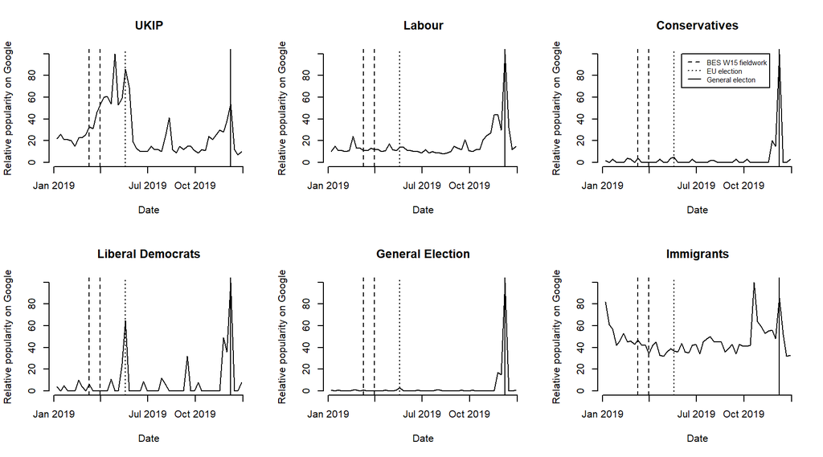

Google trends popularity of various search terms in 2019

```r
par(mfrow = c(2,3))

# UKIP

# This collects data, but since the API does not allow for a lot of calls at the same time, one needs to save the data for a later time

# res_ukip_2019 <- gtrends(c("UKIP"),geo=c("GB"), time = "2019-01-01 2019-12-31", gprop="web")

# saveRDS(res_ukip_2019, file = "gtrends/gtrends_ukip.rds")

# loading data

gtrends_ukip <- readRDS("data/gtrends_ukip.rds")

res_ukip_2019 <- gtrends_ukip$interest_over_time

res_ukip_2019 <- res_ukip_2019 %>%
    mutate(hits = as.numeric(hits), date = as.Date(date)) %>%
    replace(is.na(.), 0)

plot(
  res_ukip_2019$date,
  res_ukip_2019$hits,
  type = "l",
  xlab = "Date",
  ylab = "Relative popularity on Google",
  main = "UKIP",
  bty = "n",
  ylim = c(0, 100)
)

abline(v = c(res_ukip_2019[10, 1], res_ukip_2019[13, 1]), lty = "dashed")

abline(v = res_ukip_2019[20, 1], lty = "dotted")

abline(v = res_ukip_2019[20, 1], lty = "dotted")

abline(v = res_ukip_2019[49, 1])

# Labour

# res_labour_2019 <- gtrends(c("Labour"),geo=c("GB"), time = "2019-01-01 2019-12-31", gprop="web")

# saveRDS(res_labour_2019, file = "gtrends/gtrends_labour.rds")

gtrends_labour <- readRDS("data/gtrends_labour.rds")

res_labour_2019 <- gtrends_labour$interest_over_time

res_labour_2019 <- res_labour_2019 %>%
    mutate(hits = as.numeric(hits), date = as.Date(date)) %>%
    replace(is.na(.), 0)

plot(
  res_labour_2019$date,
  res_labour_2019$hits,
  type = "l",
  xlab = "Date",
  ylab = "Relative popularity on Google",
  main = "Labour",
  bty = "n",
  ylim = c(0, 100)
)

abline(v = c(res_labour_2019[10, 1], res_labour_2019[13, 1]), lty = "dashed")

abline(v = res_labour_2019[20, 1], lty = "dotted")

abline(v = res_labour_2019[49, 1])

# res_con_2019 <- gtrends(keyword = "Conservatives", geo=c("GB"), time = "2019-01-01 2019-12-31", gprop="web")

#saveRDS(res_con_2019, file = "gtrends/gtrends_con.rds")


gtrends_con <- readRDS("data/gtrends_con.rds")

res_con_2019 <- gtrends_con$interest_over_time

res_con_2019 <- res_con_2019 %>%
    mutate(hits = as.numeric(hits), date = as.Date(date)) %>%
    replace(is.na(.), 0)

plot(
  res_con_2019$date,
  res_con_2019$hits,
  type = "l",
  xlab = "Date",
  ylab = "Relative popularity on Google",
  main = "Conservatives",
  bty = "n",
  ylim = c(0, 100)
)

abline(v = c(res_con_2019[10, 1], res_con_2019[13, 1]), lty = "dashed")

abline(v = res_con_2019[20, 1], lty = "dotted")

abline(v = res_con_2019[49, 1])

legend(y = 100, x = res_con_2019[22, 1], legend=c("BES W15 fieldwork", "EU election", "General electon"),
       col="black", lty=c(2,3,1), cex=0.7)

# res_libdem_2019 <- gtrends(keyword = "Liberal Democrats", geo=c("GB"), time = "2019-01-01 2019-12-31", gprop="web")

# saveRDS(res_libdem_2019, file = "gtrends/gtrends_libdem.rds")

gtrends_libdem <- readRDS("data/gtrends_libdem.rds")

res_libdem_2019 <- gtrends_libdem$interest_over_time

res_libdem_2019 <- res_libdem_2019 %>%
    mutate(hits = as.numeric(hits), date = as.Date(date)) %>%
    replace(is.na(.), 0)

plot(
  res_libdem_2019$date,
  res_libdem_2019$hits,
  type = "l",
  xlab = "Date",
  ylab = "Relative popularity on Google",
  main = "Liberal Democrats",
  bty = "n",
  ylim = c(0, 100)
)

abline(v = c(res_libdem_2019[10, 1], res_libdem_2019[13, 1]), lty = "dashed")

abline(v = res_libdem_2019[20, 1], lty = "dotted")

abline(v = res_libdem_2019[49, 1])

# res_genel_2019 <- gtrends(keyword = "General Election", geo=c("GB"), time = "2019-01-01 2019-12-31", gprop="web")

# saveRDS(res_genel_2019, file = "gtrends/gtrends_genel.rds")

gtrends_genel <- readRDS("data/gtrends_genel.rds")

res_genel_2019 <- gtrends_genel$interest_over_time

res_genel_2019 <- res_genel_2019 %>%
    mutate(hits = as.numeric(hits), date = as.Date(date)) %>%
    replace(is.na(.), 0)

plot(
  res_genel_2019$date,
  res_genel_2019$hits,
  type = "l",
  xlab = "Date",
  ylab = "Relative popularity on Google",
  main = "General Election",
  bty = "n",
  ylim = c(0, 100)
)

abline(v = c(res_genel_2019[10, 1], res_genel_2019[13, 1]), lty = "dashed")

abline(v = res_genel_2019[20, 1], lty = "dotted")

abline(v = res_genel_2019[49, 1])


# res_immig_2019 <- gtrends(keyword = "Immigrants", geo=c("GB"), time = "2019-01-01 2019-12-31", gprop="web")

# saveRDS(res_immig_2019, file = "gtrends/gtrends_immig.rds")

gtrends_immig <- readRDS("data/gtrends_immig.rds")

res_immig_2019 <- gtrends_immig$interest_over_time

res_immig_2019 <- res_immig_2019 %>%
    mutate(hits = as.numeric(hits), date = as.Date(date)) %>%
    replace(is.na(.), 0)

plot(
  res_immig_2019$date,
  res_immig_2019$hits,
  type = "l",
  xlab = "Date",
  ylab = "Relative popularity on Google",
  main = "Immigrants",
  bty = "n",
  ylim = c(0, 100)
)

abline(v = c(res_immig_2019[10, 1], res_immig_2019[13, 1]), lty = "dashed")

abline(v = res_immig_2019[20, 1], lty = "dotted")

abline(v = res_immig_2019[49, 1])
```

# Adding RWA into the equation

```r
stargazer(mod1, mod1_a, mod2_a, type = "latex", no.space = T, font.size = "tiny", omit.stat=c("ser","f"), star.char = c("*", "**", "***"), star.cutoffs = c(.05, .01, .001), notes = c("\\parbox[t]{4cm}{*p < .05, **p < .01, ***p < .001}", "Standard errors in parentheses", "Reference categories: Education - No Qualification"), notes.append = F, dep.var.labels=c("SDO", "RWA"),covariate.labels=c("GRD","RWAw14", "IRD", "Female", "Age", "Below university education", "University education", "Unspecified education", "Household income", "Urban"), header = F, title = "Robustness ckeck incuding RWA using Wave 15 and Wave 21 data", out = "figures/tab1_rwa.html")
```

# Analysing ethnic minorities

```r
# analysis of the sample by ethnic group

t1 <- t.test(sdo ~ p_ethnicity, data = bes_full) # no difference between

mod_inc <- lm(sdo ~ factor(p_gross_household), data = bes_full[bes_full$p_ethnicity == 0,]) # no difference

t2 <- t.test(grd ~ p_ethnicity, data = bes_full) # grd is higher for White Britons

t3 <- t.test(immig_att ~ p_ethnicity, data = bes_full) # prejudice is higher for White Britons

mod1_test <- lm(sdo ~ grd * p_ethnicity + ird + gender + age + factor(p_education) + p_gross_household + urban, data = bes_full)

# grd does not have differential effects between groups

mod2_test <- lm(immig_att ~ sdo*p_ethnicity  + gender + age + factor(p_education) + p_gross_household + urban , data = bes_full) # high-sdo white britons tend to be more anti-immigrant than high-sdo non-white brits but this is only significant at p < 0.10


tidytab <- rbind(tidy(t1), tidy(t2), tidy(t3))

tidytab <- tidytab[,c(1,2,3,7,8)]

rownames(tidytab) <- c("SDO", "GRD", "Prejudice")

colnames(tidytab) <- c("Difference", "non-White mean", "White Mean", "95% CI low", "95% CI high")

tidytab <- round(tidytab, 2)

kbl(tidytab, row.names = T) %>%
  kable_classic(full_width = F, html_font = "Cambria") %>%
  add_footnote("Two-sided t-tests.", notation="none") %>%
  cat(., file = "figures/t_res.html")

kbl(tidytab, booktabs = T, linesep = "", row.names = T) %>%
  kable_classic(full_width = F, html_font = "Cambria") %>%
  add_footnote("Two-sided t-tests.", notation="none")
```

|  | Difference | non-White mean | White Mean | 95% CI low | 95% CI high |
| --- | --- | --- | --- | --- | --- |
| 1 | -0.02 | 0.32 | 0.34 | -0.04 | 0.01 |
| 2 | -0.08 | 0.43 | 0.51 | -0.12 | -0.05 |
| 3 | -0.16 | 0.27 | 0.43 | -0.19 | -0.12 |

Two-sided t-tests.

```r
stargazer(mod_inc, type = "latex", no.space = T, font.size = "tiny", omit.stat=c("ser","f"), star.char = c("*", "**", "***"), star.cutoffs = c(.05, .01, .001), notes = c("\\parbox[t]{4cm}{*p < .05, **p < .01, ***p < .001}"), notes.append = F, dep.var.labels="SDO", header = F, title = "SDO distribution in the ethnic minority group dependent on their class", out = "figures/tab_inc.html")
```

```r
stargazer(mod1_test, mod2_test, type = "latex", no.space = T, font.size = "tiny", omit.stat=c("ser","f"), star.char = c("*", "**", "***"), star.cutoffs = c(.05, .01, .001), notes = c("\\parbox[t]{4cm}{*p < .05, **p < .01, ***p < .001}", "Standard errors in parentheses", "Reference categories: Education - No Qualification"), notes.append = F, dep.var.labels=c("SDO","Prejudice"),covariate.labels=c("GRD", "SDO", "White Briton", "IRD" , "Female", "Age", "Below university education", "University education", "Unspecified education", "Household income","Urban", "GRD*White Briton", "SDO*White Briton"), header = F, title = "Models 1 and 2 including ethnic minorities and an interaction between ethnic minority status and GRD/SDO", out = "figures/tab1_test.html")
```

```r
mod1_full <- lm(sdo ~ grd + ird + gender + age + factor(p_education) + p_gross_household + factor(urban) + p_ethnicity, data = bes_full)


mod2_full <- lm(immig_att ~ sdo  + gender + age + factor(p_education) + p_gross_household + factor(urban) + p_ethnicity, data = bes_full)


# this prepares the data for a multinomial logit

bes_full$generalElectionVote <- factor(bes_full$generalElectionVote)
bes_full$generalElectionVote <- relevel(bes_full$generalElectionVote, ref = "0")

# turns data into the "wide" format

bes2_full <- mlogit.data(data = bes_full, choice = "generalElectionVote", shape = "wide")

# and runs the multinomial logit regression
# here, it only has chooser(individual)-specific covariates

mod3_full <- mlogit(generalElectionVote ~ 0 | immig_att + gender + age + factor(p_education) + p_gross_household + factor(urban) + p_ethnicity, data = bes2_full,  reflevel = "0")


# simulating again...

S <- sim_func(nsim, coef(mod3_full), varcov = vcov(mod3_full))

J <- length(unique(bes_full$generalElectionVote))  # Number of categories
k <- 10 # number of independent variables + intercept


# store in an array
beta_S <- array(0, dim = c(J, k, nsim))


# check dimensions
dim(beta_S)
```

[1] 8 10 1000

```r
# fill the array with the sampling distribution of betas
for(sim in 1:nsim) {
  beta_S[-1, ,sim] <- matrix(S[sim,],
                             ncol = k,
                             byrow = F)
}

# OVA again

X <- as.matrix(cbind(1, bes_full$immig_att, bes_full$gender, bes_full$age, dummy_cols(bes_full$p_education)[,-c(1,2)],bes_full$p_gross_household, bes_full$urban, bes_full$p_ethnicity))

# Set up your scenarios
n_scenarios <- 2 # Number of scenarios
cases <- array(NA, c(dim(X),
                     n_scenarios))

# put in te OVA dataset as all of the scenarios

cases[, , ] <- X

# selecting which column has the immigration attitudes

sel <- 2

cases[, sel, 1] <- rnorm(n = nrow(bes_full), mean = mean(val2[,1]), sd = sd(val2[,1]))
cases[, sel, 2] <- rnorm(n = nrow(bes_full), mean = mean(val2[,2]), sd = sd(val2[,2]))

V  <-
  array(NA,
        dim = c(nrow(X),       # number of observations
                J,             # number of categories
                nsim,          # number of simulations
                n_scenarios))  # number of scenarios

# loop over the scenarios
for(i in 1:n_scenarios){
  V[,,,i] <- apply(beta_S[,,], c(1,3),
                   function(bs) cases[,,i] %*% bs)
}

# dimensions again
dim(V)
```

[1] 2647 8 1000 2

```r
# sum of all of the expected utilities to vote for parties
Sexp <- apply(V, c(1,3,4), function(v) sum(exp(v)))



# predicted probabilities of voting for each party
P <- array(NA, c(nsim, J, 2))
for (scen in 1:n_scenarios) {
  for (category in 1:J) {
    P[, category, scen] <-
      apply(exp(V[, category, , scen]) / Sexp[, , scen], 2, mean)
  }
}
# quantities of interest
# low prejudice voters
QoI0Mean <- apply(P[, , 1], 2, mean)
QoI0CI <-
  apply(P[, , 1], 2, function(x)
    quantile(x, probs = c(0.025, 0.975)))
# high prejudice voters
QoI1Mean <- apply(P[, , 2], 2, mean)
QoI1CI <-
  apply(P[, , 2], 2, function(x)
    quantile(x, probs = c(0.025, 0.975)))


stargazer(mod1_full, mod2_full, type = "latex", no.space = T, font.size = "tiny", omit.stat=c("ser","f"), star.char = c("*", "**", "***"), star.cutoffs = c(.05, .01, .001), notes = c("\\parbox[t]{4cm}{*p < .05, **p < .01, ***p < .001}", "Standard errors in parentheses", "Reference categories: Education - No Qualification"), notes.append = F, dep.var.labels=c("SDO","Prejudice"),covariate.labels=c("GRD", "IRD", "SDO", "Female", "Age", "Below university education", "University education", "Unspecified education", "Household income","Urban", "White Briton"), header = F, title = "Models 1 and 2 including ethnic minorities", out = "figures/tab1_full.html")
```

```r
stargazer(mod3_full, type = "latex", no.space = T, font.size = "tiny", single.row = T, star.char = c("*", "**", "***"), star.cutoffs = c(.05, .01, .001), notes = c("\\parbox[t]{4cm}{*p < .05, **p < .01, ***p < .001}", "Standard errors in parentheses", "Reference categories: Education - No Qualification", "Vote choice - Would not vote"), notes.append = F, dep.var.labels=c("General election vote"),covariate.labels=c("Intercept: Conservatives", "Intercept: Labour", "Intercept: LibDem", "Intercept: Plaid Cymru", "Intercept: UKIP", "Intercept: Greens", "Intercept: Other party", "Prejudice: Conservatives", "Prejudice: Labour", "Prejudice: LibDem", "Prejudice: Plaid Cymru", "Prejudice: UKIP", "Prejudice: Greens", "Prejudice: Other party", "Female: Conservatives", "Female: Labour", "Female: LibDem", "Female: Plaid Cymru", "Female: UKIP", "Female: Greens", "Female: Other party", "Age: Conservatives", "Age: Labour", "Age: LibDem", "Age: Plaid Cymru", "Age: UKIP", "Age: Greens", "Age: Other party", "Below university education: Conservatives", "Below university education: Labour", "Below university education: LibDem", "Below university education: Plaid Cymru", "Below university education: UKIP", "Below university education: Greens", "Below university education: Other party", "University education: Conservatives", "University education: Labour", "University education: LibDem", "University education: Plaid Cymru", "University education: UKIP", "University education: Greens", "University education: Other party", "Unspecified education: Conservatives", "Unspecified education: Labour", "Unspecified education: LibDem", "Unspecified education: Plaid Cymru", "Unspecified education: UKIP", "Unspecified education: Greens", "Unspecified education: Other party", "Household income: Conservatives", "Household income: Labour", "Household income: LibDem", "Household income: Plaid Cymru", "Household income: UKIP", "Household income: Greens", "Household income: Other party", "Urban: Conservatives", "Urban: Labour", "Urban: LibDem", "Urban: Plaid Cymru", "Urban: UKIP", "Urban: Greens", "Urban: Other party", "White Briton: Conservatives", "White Briton: Labour", "White Briton: LibDem", "White Briton: Plaid Cymru", "White Briton: UKIP", "White Briton: Greens", "White Briton: Other party"), header = F, title = "Model 3 including ethnic minorities", out = "figures/tab2_full.html")
```

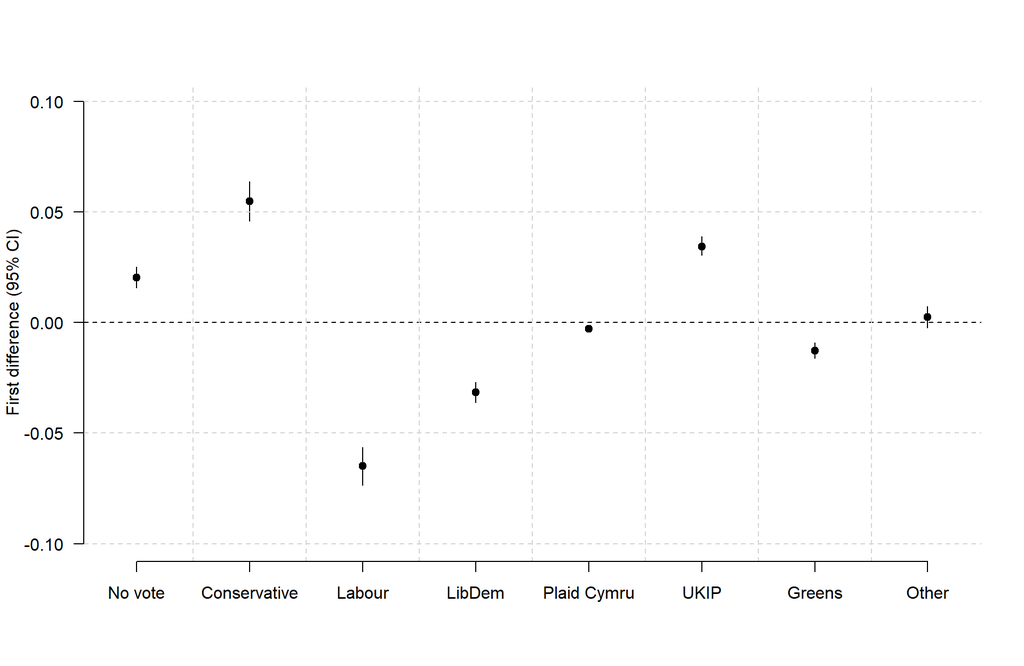

First differences in predicted probabilities of vote intention based on prejudice scenarios with ethnic minoritis included

```r
# first differences again, yayyy
QoIFD <- P[, , 2] - P[, , 1]

QoIFDMean <- apply(QoIFD, 2, mean)

QoIFDCI <-
  apply(QoIFD, 2, function(x)
    quantile(x, probs = c(0.025, 0.975)))

fd_seq <- seq(0,1, length.out = length(QoIFDMean))

plot(
  x = fd_seq,
  y = QoIFDMean,
  xlim = c(-0.025, 1.025),
  ylim = c(-0.1, 0.1),
  xaxt = "n",
  bty = "n",
  las = 1,
  xlab = "",
  ylab = "First difference (95% CI)",
  main = "",
  font.main = 1
)

abline(h = 0, lwd = 1, lty = "dashed", col = "black")
points(
  x = fd_seq,
  y = QoIFDMean,
  pch = 19,
  cex = 1
)

segments(
  x0 = fd_seq,
  y0 = QoIFDCI[1,],
  y1 = QoIFDCI[2,],
  lwd = 1,
  lend = 1
)
abline(v = fd_seq + (fd_seq[1]-fd_seq[2])/2,
       lty = "dashed",
       col = "lightgrey")
abline(h = seq(0.05,1, by = 0.05), lty = "dashed",
       col = "lightgrey")
abline(h = seq(-1,-0.05, by = 0.05), lty = "dashed",
       col = "lightgrey")

axis(1, fd_seq, labels = c("No vote", "Conservative", "Labour", "LibDem", "Plaid Cymru", "UKIP", "Greens", "Other"))
```

# Objective vs subjective economics

```r
bes_income <- readRDS("data/besW15_income.rds")


mod_income <- polr(
  as.factor(p_gross_household) ~ p_ethnicity + as.factor(p_education) + gender + age,
  data = bes_income
)

summary(mod_income)
```

```
##
## Re-fitting to get Hessian
```

```
## Call:
## polr(formula = as.factor(p_gross_household) ~ p_ethnicity + as.factor(p_education) +
##     gender + age, data = bes_income)
##
## Coefficients:
##                            Value Std. Error t value
## p_ethnicity              0.14479  0.0425297   3.404
## as.factor(p_education)2  0.80959  0.0551728  14.674
## as.factor(p_education)3  1.70987  0.0573160  29.832
## as.factor(p_education)4  1.34878  0.0614556  21.947
## gender                  -0.45518  0.0243577 -18.687
## age                     -0.02207  0.0008008 -27.560
##
## Intercepts:
##     Value    Std. Error t value
## 1|2  -1.5796   0.0891   -17.7357
## 2|3  -0.5802   0.0887    -6.5426
## 3|4   0.4971   0.0884     5.6226
##
## Residual Deviance: 60644.35
## AIC: 60662.35
```

```r
nsim <- 1000

S <- mvrnorm(nsim, c(coef(mod_income), mod_income$zeta), vcov(mod_income))
```

```
##
## Re-fitting to get Hessian
```

```r
ethnicity_seq <- c(0, 1)


X <- mod_income$model


X <- cbind(X$p_ethnicity, dummy_cols(X$`as.factor(p_education)`)[,-c(1,2)], X$gender, X$age)

X <- as.matrix(X)

cases <- array(NA, c(dim(X), length(ethnicity_seq)))

cases[, ,] <- X

# Change the ethnicity of everyone

for (i in 1:length(ethnicity_seq)) {
  cases[, 1, i] <- ethnicity_seq[i]
}

U <- array(dim = c(nrow(X), nsim, length(ethnicity_seq)))

for (i in 1:length(ethnicity_seq)) {
  U[, , i] <- apply(S[, 1:6], 1, function(s)
    cases[, , i] %*% s)
}

tau <- S[, 7:9]

ncat <- ncol(tau) + 1

probs <- array(NA, c(ncat, nsim, length(ethnicity_seq)))


for (i in 1:length(ethnicity_seq)) {
  # calculate probabilities
  probs[1, , i] <-
    apply(exp(tau[, 1] - U[, , i]) / (1 + exp(tau[, 1] - U[, , i])), 2, mean)

  for (j in 2:(ncat - 1)) {
    probs[j, , i] <-
      apply(exp(tau[, j] - U[, , i]) / (1 + exp(tau[, j] - U[, , i])) -
        exp(tau[,j - 1] - U[, , i]) / (1 + exp(tau[,j - 1] - U[, , i])), 2, mean)
  }

  probs[ncat, , i] <-
    apply(1 - exp(tau[, ncat - 1] - U[, , i]) /
            (1 + exp(tau[, ncat - 1] - U[, , i])), 2, mean)
}

fd <- probs[,,2] - probs[,,1]

fd_mean <- rowMeans(fd)*100

fd_quantiles <- apply(fd, 1, quantile, c(0.025, 0.975))*100
```

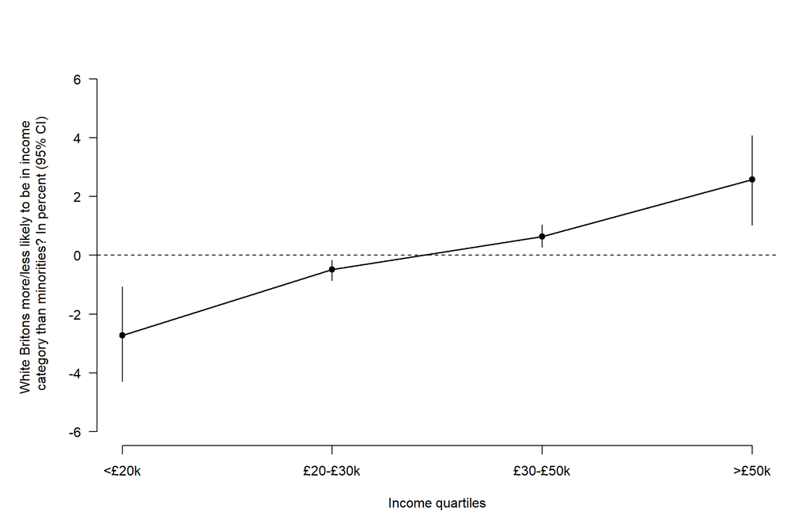

Results of an ordinal logit comparing White Britons and ethnic minorities in their probability to report income in given quartiles

```r
# plotting

par(mar = c(5, 6, 4, 2))

plot(y = fd_mean,
     x = seq(-5,5, length.out = 4),
       xaxt = "n",
  bty = "n",
  las = 1,
  xlab = "Income quartiles",
  ylab = "White Britons more/less likely to be in income \n category than minorities? In percent (95% CI)",
  main = "",
  font.main = 1,
  ylim = c(-6,6)
     )

points(
  x = seq(-5,5, length.out = 4),
  y = fd_mean,
  pch = 19,
  cex = 1
)

lines(
  x = seq(-5, 5, length.out = 4),
  y = fd_mean,
  lwd = 1.5
)

segments(
  x0 = seq(-5,5, length.out = 4),
  y0 = fd_quantiles[1,],
  y1 = fd_quantiles[2,],
  lwd = 1,
  lend = 1
)

abline(h = 0, lty = "dashed")

axis(side = 1, at = seq(-5,5, length.out = 4), labels = c("<£20k", "£20-£30k", "£30-£50k", ">£50k"))
```

# Considering alternative theoretical paths

```r
# Making radical right vote choice binary

bes_auth$rr_vote <- ifelse(bes_auth$generalElectionVote == 6, 1, 0)

# Dummies for education

bes_auth <- dummy_cols(bes_auth,
                   select_columns = "p_education")



# Running the SEM

main_psem <- psem(
  lm(grd ~ sdo + auth + ird + gender + age + p_education_2 +  p_education_3 +  p_education_4 + p_gross_household + urban , data = bes_auth),

  lm(immig_att ~  sdo + auth + grd  + ird + gender + age + p_education_2 +  p_education_3 +  p_education_4 + p_gross_household + urban , data = bes_auth),

  glm(rr_vote ~ grd + sdo + auth + immig_att + ird + gender + age + p_education_2 +  p_education_3 +  p_education_4 + p_gross_household + urban, family = binomial(link = "logit"), data = bes_auth),

  data = bes

)


# Table for the results

coefs_psem <- summary(main_psem)$coefficients

coefs_psem <- coefs_psem[,-c(5, 8)]

coefs_psem <- modify_if(coefs_psem, ~is.numeric(.), ~round(., 2))

coefs_psem[,1] <- c("GRD", "GRD","GRD","GRD","GRD","GRD","GRD","GRD", "GRD", "GRD", "Prejudice", "Prejudice","Prejudice","Prejudice","Prejudice","Prejudice","Prejudice","Prejudice", "Prejudice", "Prejudice", "Prejudice", "RRV", "RRV","RRV","RRV","RRV","RRV","RRV","RRV","RRV","RRV", "RRV", "RRV")

coefs_psem[,2] <- c("SDO", "RWA" , "IRD", "Female", "Age", "Below university education", "University education", "Unspecified education", "Household income", "Urban", "SDO", "RWA", "GRD", "IRD", "Female", "Age", "Below university education", "University education", "Unspecified education", "Household income", "Urban", "GRD", "SDO", "RWA", "Prejudice", "IRD", "Female", "Age", "Below university education", "University education", "Unspecified education", "Household income", "Urban")

kbl(coefs_psem) %>%
  kable_classic(full_width = F, html_font = "Cambria") %>%
  add_footnote("Models fit using piecewiseSEM. RRV = Radical right vote. *p < .05, **p < 0.01 , ***p < 0.001", notation="none") %>%
  cat(., file = "figures/sem_res2.html")

r2_psem <- summary(main_psem)$R2

kbl(r2_psem) %>%
  kable_classic(full_width = F, html_font = "Cambria")
```

| Response | family | link | method | R.squared |
| --- | --- | --- | --- | --- |
| grd | gaussian | identity | none | 0.30 |
| immig_att | gaussian | identity | none | 0.40 |
| rr_vote | binomial | logit | nagelkerke | 0.26 |

```r
library(DiagrammeR)
library(DiagrammeRsvg)
library(rsvg)
library(magrittr)

SEM_plot <- grViz("
digraph CFA{

# main
node [shape=rectangle]
GRD;
SDO;
Prejudice;
RRV;

#regressions
SDO -> GRD [label='0.16***'];
SDO -> Prejudice [label='0.31***'];

GRD -> Prejudice [label='0.31***'];
GRD -> RRV [label='1.02*'];

Prejudice -> RRV [label='2.67***']

}
")

SEM_plot %>%
export_svg() %>%
charToRaw %>%
rsvg_pdf("figures/fig_sem_alt.pdf")
```

# Adding left-right orientation as a control

```r
# number 1, GRD -> SDO

mod1_lr <- lm(sdo ~ grd + ird + leftRight + gender + age + factor(p_education) + p_gross_household + factor(urban), data = bes_lr)

# summary for checking results. note that the labels here are not informative

summary(mod1_lr)
```

```
##
## Call:
## lm(formula = sdo ~ grd + ird + leftRight + gender + age + factor(p_education) +
##     p_gross_household + factor(urban), data = bes_lr)
##
## Residuals:
##      Min       1Q   Median       3Q      Max
## -0.55990 -0.10340  0.00219  0.10720  0.67634
##
## Coefficients:
##                        Estimate Std. Error t value Pr(>|t|)
## (Intercept)           0.1631981  0.0254287   6.418 1.67e-10 ***
## grd                   0.0941530  0.0155409   6.058 1.60e-09 ***
## ird                  -0.0230771  0.0178719  -1.291 0.196746
## leftRight             0.0412246  0.0014898  27.672  < 2e-16 ***
## gender               -0.0211248  0.0066127  -3.195 0.001419 **
## age                  -0.0002447  0.0002223  -1.101 0.270985
## factor(p_education)2 -0.0290400  0.0143301  -2.026 0.042827 *
## factor(p_education)3 -0.0551945  0.0149246  -3.698 0.000222 ***
## factor(p_education)4 -0.0249380  0.0163953  -1.521 0.128383
## p_gross_household     0.0012672  0.0009878   1.283 0.199652
## factor(urban)1       -0.0008950  0.0075483  -0.119 0.905629
## ---
## Signif. codes:  0 '***' 0.001 '**' 0.01 '*' 0.05 '.' 0.1 ' ' 1
##
## Residual standard error: 0.1573 on 2337 degrees of freedom
## Multiple R-squared:  0.3328, Adjusted R-squared:   0.33
## F-statistic: 116.6 on 10 and 2337 DF,  p-value: < 2.2e-16
```

```r
mod2_lr <- lm(immig_att ~ sdo + leftRight + gender + age + factor(p_education) + p_gross_household + factor(urban), data = bes_lr)

# summary for checking results. note that the labels here are not informative

summary(mod2_lr)
```

```
##
## Call:
## lm(formula = immig_att ~ sdo + leftRight + gender + age + factor(p_education) +
##     p_gross_household + factor(urban), data = bes_lr)
##
## Residuals:
##      Min       1Q   Median       3Q      Max
## -0.77937 -0.17039 -0.01951  0.15560  0.84374
##
## Coefficients:
##                        Estimate Std. Error t value Pr(>|t|)
## (Intercept)           0.1516492  0.0390141   3.887 0.000104 ***
## sdo                   0.4269714  0.0324872  13.143  < 2e-16 ***
## leftRight             0.0364953  0.0026775  13.630  < 2e-16 ***
## gender               -0.0128394  0.0104878  -1.224 0.220989
## age                   0.0012971  0.0003509   3.696 0.000224 ***
## factor(p_education)2 -0.0573501  0.0227077  -2.526 0.011616 *
## factor(p_education)3 -0.1176223  0.0236746  -4.968 7.24e-07 ***
## factor(p_education)4 -0.0885165  0.0259719  -3.408 0.000665 ***
## p_gross_household    -0.0088217  0.0015462  -5.705 1.31e-08 ***
## factor(urban)1        0.0144637  0.0119498   1.210 0.226256
## ---
## Signif. codes:  0 '***' 0.001 '**' 0.01 '*' 0.05 '.' 0.1 ' ' 1
##
## Residual standard error: 0.2491 on 2338 degrees of freedom
## Multiple R-squared:  0.3191, Adjusted R-squared:  0.3165
## F-statistic: 121.7 on 9 and 2338 DF,  p-value: < 2.2e-16
```

```r
# this prepares the data for a multinomial logit

bes_lr$generalElectionVote <- factor(bes_lr$generalElectionVote)
bes_lr$generalElectionVote <- relevel(bes_lr$generalElectionVote, ref = "0")

# turns data into the "wide" format

bes2_lr <- mlogit.data(data = bes_lr, choice = "generalElectionVote", shape = "wide")

# and runs the multinomial logit regression
# here, it only has chooser(individual)-specific covariates

mod3_lr <- mlogit(generalElectionVote ~ 0 | immig_att + leftRight + gender + age + factor(p_education) + p_gross_household + factor(urban), data = bes2_lr,  reflevel = "0")

summary(mod3_lr)
```

```
##
## Call:
## mlogit(formula = generalElectionVote ~ 0 | immig_att + leftRight +
##     gender + age + factor(p_education) + p_gross_household +
##     factor(urban), data = bes2_lr, reflevel = "0", method = "nr")
##
## Frequencies of alternatives:choice
##        0        1        2        3        5        6        7        9
## 0.060051 0.314310 0.290460 0.117121 0.008092 0.105622 0.050681 0.053663
##
## nr method
## 8 iterations, 0h:0m:2s
## g'(-H)^-1g = 1.89E-06
## successive function values within tolerance limits
##
## Coefficients :
##                          Estimate Std. Error  z-value  Pr(>|z|)
## (Intercept):1          -3.3843220  0.7492458  -4.5170 6.273e-06 ***
## (Intercept):2           5.5754336  0.7715381   7.2264 4.960e-13 ***
## (Intercept):3           1.7651527  0.8859125   1.9925 0.0463197 *
## (Intercept):5          -0.5085685  2.0101778  -0.2530 0.8002707
## (Intercept):6          -3.6053881  0.8677101  -4.1551 3.252e-05 ***
## (Intercept):7           3.4536446  1.0469822   3.2987 0.0009715 ***
## (Intercept):9          -2.0630924  1.0183855  -2.0258 0.0427805 *
## immig_att:1            -0.4640043  0.3569248  -1.3000 0.1935991
## immig_att:2            -2.9061810  0.3963635  -7.3321 2.265e-13 ***
## immig_att:3            -4.3592182  0.4687971  -9.2987 < 2.2e-16 ***
## immig_att:5            -4.3317245  1.3310798  -3.2543 0.0011367 **
## immig_att:6             2.4040113  0.4247307   5.6601 1.513e-08 ***
## immig_att:7            -4.6480701  0.6318481  -7.3563 1.890e-13 ***
## immig_att:9            -1.2193569  0.4810452  -2.5348 0.0112509 *
## leftRight:1             0.4060411  0.0544795   7.4531 9.126e-14 ***
## leftRight:2            -0.5950652  0.0585657 -10.1606 < 2.2e-16 ***
## leftRight:3            -0.1883395  0.0616388  -3.0555 0.0022466 **
## leftRight:5            -0.4805214  0.1507796  -3.1869 0.0014380 **
## leftRight:6             0.2946904  0.0623376   4.7273 2.275e-06 ***
## leftRight:7            -0.4184372  0.0761132  -5.4976 3.851e-08 ***
## leftRight:9             0.0814303  0.0706967   1.1518 0.2493921
## gender:1                0.3289186  0.1931581   1.7028 0.0885967 .
## gender:2                0.1295741  0.2054593   0.6307 0.5282655
```

[output cut: 38 more lines]

```
## p_gross_household:7     0.0174746  0.0402395   0.4343 0.6640970
## p_gross_household:9     0.1508444  0.0388028   3.8875 0.0001013 ***
## factor(urban)1:1        0.1242371  0.2189288   0.5675 0.5703901
## factor(urban)1:2        0.2078394  0.2345164   0.8862 0.3754845
## factor(urban)1:3       -0.0957293  0.2498762  -0.3831 0.7016405
## factor(urban)1:5       -1.0631080  0.5159040  -2.0607 0.0393345 *
## factor(urban)1:6       -0.2520272  0.2475377  -1.0181 0.3086130
## factor(urban)1:7        0.2135708  0.3150956   0.6778 0.4979005
## factor(urban)1:9       -0.3146931  0.2779984  -1.1320 0.2576362
## ---
## Signif. codes:  0 '***' 0.001 '**' 0.01 '*' 0.05 '.' 0.1 ' ' 1
##
## Log-Likelihood: -3096.3
## McFadden R^2:  0.23662
## Likelihood ratio test : chisq = 1919.5 (p.value = < 2.22e-16)
```

```r
stargazer(mod1_lr, mod2_lr, type = "latex", no.space = T, font.size = "tiny", omit.stat=c("ser","f"), star.char = c("*", "**", "***"), star.cutoffs = c(.05, .01, .001), notes = c("\\parbox[t]{4cm}{*p < .05, **p < .01, ***p < .001}", "Standard errors in parentheses", "Reference categories: Education - No Qualification"), notes.append = F, dep.var.labels=c("SDO","Prejudice"),covariate.labels=c("GRD", "IRD",  "SDO", "Left-Right ID", "Female", "Age", "Below university education", "University education", "Unspecified education", "Household income"), header = F, title = "Models 1 and 2 including left-right identification as a control variable", out = "figures/tab1_lr.html")
```

```r
stargazer(mod3_lr, type = "latex", no.space = T, font.size = "tiny", single.row = T, star.char = c("*", "**", "***"), star.cutoffs = c(.05, .01, .001), notes = c("\\parbox[t]{4cm}{*p < .05, **p < .01, ***p < .001}", "Standard errors in parentheses", "Reference categories: Education - No Qualification", "Vote choice - Would not vote"), notes.append = F, dep.var.labels=c("General election vote"),covariate.labels=c("Intercept: Conservatives", "Intercept: Labour", "Intercept: LibDem", "Intercept: Plaid Cymru", "Intercept: UKIP", "Intercept: Greens", "Intercept: Other party", "Prejudice: Conservatives", "Prejudice: Labour", "Prejudice: LibDem", "Prejudice: Plaid Cymru", "Prejudice: UKIP", "Prejudice: Greens", "Prejudice: Other party", "Left-Right ID: Conservatives", "Left-Right ID: Labour", "Left-Right ID: LibDem", "Left-Right ID: Plaid Cymru", "Left-Right ID: UKIP", "Left-Right ID: Greens", "Left-Right ID: Other party", "Female: Conservatives", "Female: Labour", "Female: LibDem", "Female: Plaid Cymru", "Female: UKIP", "Female: Greens", "Female: Other party", "Age: Conservatives", "Age: Labour", "Age: LibDem", "Age: Plaid Cymru", "Age: UKIP", "Age: Greens", "Age: Other party", "Below university education: Conservatives", "Below university education: Labour", "Below university education: LibDem", "Below university education: Plaid Cymru", "Below university education: UKIP", "Below university education: Greens", "Below university education: Other party", "University education: Conservatives", "University education: Labour", "University education: LibDem", "University education: Plaid Cymru", "University education: UKIP", "University education: Greens", "University education: Other party", "Unspecified education: Conservatives", "Unspecified education: Labour", "Unspecified education: LibDem", "Unspecified education: Plaid Cymru", "Unspecified education: UKIP", "Unspecified education: Greens", "Unspecified education: Other party", "Household income: Conservatives", "Household income: Labour", "Household income: LibDem", "Household income: Plaid Cymru", "Household income: UKIP", "Household income: Greens", "Household income: Other party" ), header = F, title = "Model 3 including left-right identification as a control variable", out = "figures/tab2_lr.html")
```

[^1]: University of Mannheim, domantas.undzenas@uni-mannheim.de